# lab3_Adam_Banwell

Adam Banwell

9/30/2021

## Part one: Extracting and loading data

#Use ggplot2 to create the plots, and dplyr to manipulate the data frame

```r
library(dplyr)
```

```r
library(ggplot2)
data <- readxl::read_xls('C:/Users/abanwell.DESKTOP-RUCAQHC/Desktop/ds202/ds202_lab3/GSS.xls')
data
```

```
## # A tibble: 64,814 x 5
##    Marital_status Highest_year_of_school_~ Respondents_sex Political_party_affi~
##    <chr>          <chr>                    <chr>           <chr>
##  1 Never married  16                       Female          Ind,near dem
##  2 Married        10                       Male            Not str democrat
##  3 Married        12                       Female          Independent
##  4 Married        17                       Female          Not str democrat
##  5 Married        12                       Female          Strong democrat
##  6 Never married  14                       Male            Ind,near dem
##  7 Divorced       13                       Male            Ind,near dem
##  8 Never married  16                       Male            Ind,near dem
##  9 Never married  12                       Female          Strong democrat
## 10 Married        12                       Female          Strong democrat
## # ... with 64,804 more rows, and 1 more variable: General_happiness <chr>
```

## Part two: Exploration

#Question 1

#Find the average years of education for the respondents with each marital status. Arrange your output in a meaningful order and print. Describe any patterns you find.

```r
#remove no answers and convert character string to int for mean calculation
averageYears = data %>% filter(!is.na(as.numeric(Highest_year_of_school_completed)))
averageYears = averageYears[!(averageYears$Marital_status=="No answer"),]
averageYears$Highest_year_of_school_completed = as.integer(averageYears$Highest_year_of_school_completed)

group_by(averageYears, Marital_status) %>% summarise('average years of education' = mean(Highest_year_of_school_completed))
```

```
## # A tibble: 5 x 2
##   Marital_status `average years of education`
##   <chr>                                 <dbl>
## 1 Divorced                               13.1
## 2 Married                                13.0
## 3 Never married                          13.4
## 4 Separated                              11.9
## 5 Widowed                                11.2
```

After removing the marital status “no answer” it can be seen that people who never married had the highest average years of education. The people with the lowest average years were unfortunately widowed.

#Question 2

#Create a single data frame containing records for the better educated respondents with each marital status. A “better educated” respondent is someone who has strictly more years of education than the average among those with the same marital status. Print the structure of the data frame.

```r
d = data %>% filter(!is.na(as.numeric(Highest_year_of_school_completed)))
d = d[!(d$Marital_status=="No answer"),]
d$Highest_year_of_school_completed = as.integer(d$Highest_year_of_school_completed)

#remove any rows for specified marital status with years completed less than average for that category
d = d[!(d$Marital_status=='Divorced' & d$Highest_year_of_school_completed<=13.1),]
d = d[!(d$Marital_status=='Married' & d$Highest_year_of_school_completed<=13.0),]
d = d[!(d$Marital_status=='Never married' & d$Highest_year_of_school_completed<=13.4),]
d = d[!(d$Marital_status=='Separated' & d$Highest_year_of_school_completed<=11.9),]
d = d[!(d$Marital_status=='Widowed' & d$Highest_year_of_school_completed<=11.2),]
d
```

```
## # A tibble: 28,132 x 5
##    Marital_status Highest_year_of_school_~ Respondents_sex Political_party_affi~
##    <chr>                             <int> <chr>           <chr>
##  1 Never married                        16 Female          Ind,near dem
##  2 Married                              17 Female          Not str democrat
##  3 Never married                        14 Male            Ind,near dem
##  4 Never married                        16 Male            Ind,near dem
##  5 Married                              14 Male            Strong democrat
##  6 Married                              14 Male            Ind,near rep
##  7 Married                              17 Female          Ind,near dem
##  8 Never married                        14 Female          Ind,near rep
##  9 Married                              16 Female          Strong republican
## 10 Married                              14 Female          Ind,near rep
## # ... with 28,122 more rows, and 1 more variable: General_happiness <chr>
```

#Question 3

#How is the happiness of a respondent related to his/her marriage status? Define that a person is happy if the response to question is “Very happy” or “Pretty happy”.

```r
happiness = data %>% select(Marital_status, General_happiness)
happiness = happiness[!(happiness$General_happiness=="No answer"),]
happiness = happiness[!(happiness$Marital_status=="No answer"),]

#numerical summary
happiness %>% count(Marital_status, General_happiness, sort = TRUE)%>% print(n=35)
```

```
## # A tibble: 25 x 3
##    Marital_status General_happiness     n
##    <chr>          <chr>             <int>
##  1 Married        Pretty happy      16493
##  2 Married        Very happy        12849
##  3 Never married  Pretty happy       7954
##  4 Divorced       Pretty happy       4683
##  5 Widowed        Pretty happy       3275
##  6 Never married  Very happy         2732
##  7 Married        Not too happy      2431
##  8 Married        Not applicable     2221
##  9 Never married  Not too happy      2055
## 10 Divorced       Very happy         1497
## 11 Divorced       Not too happy      1450
## 12 Widowed        Very happy         1400
## 13 Separated      Pretty happy       1148
## 14 Widowed        Not too happy      1140
## 15 Never married  Not applicable      992
## 16 Divorced       Not applicable      688
## 17 Separated      Not too happy       588
## 18 Separated      Very happy          339
## 19 Widowed        Not applicable      331
## 20 Separated      Not applicable      146
## 21 Married        Don't know           12
## 22 Never married  Don't know           10
## 23 Separated      Don't know            7
## 24 Widowed        Don't know            6
## 25 Divorced       Don't know            3
```

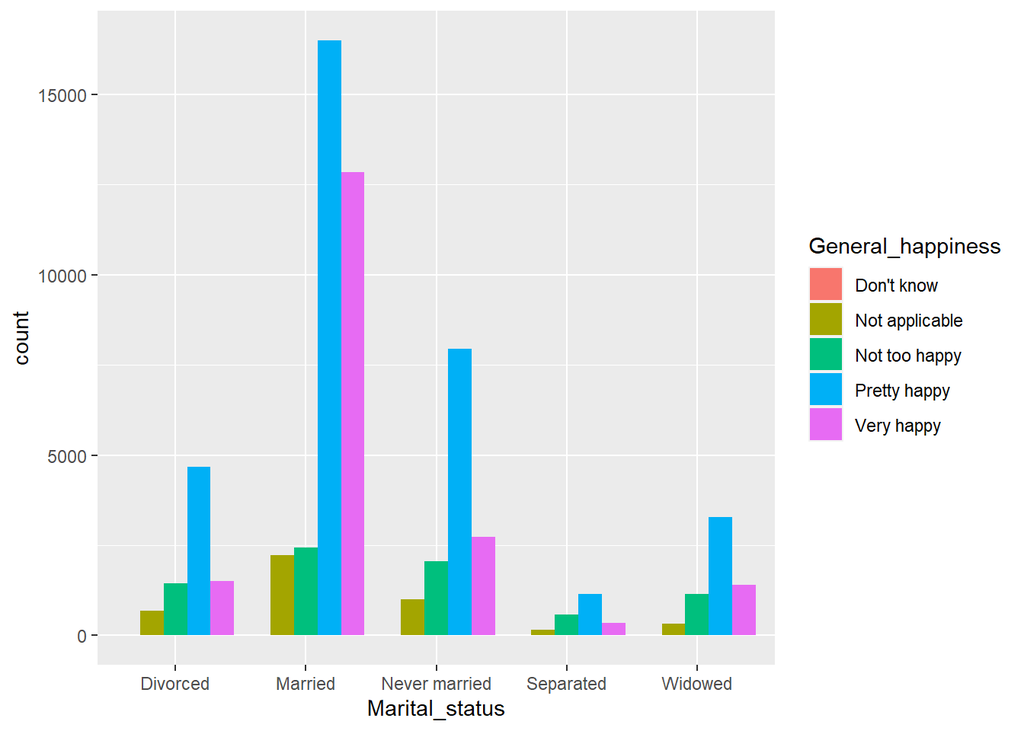

```r
#appropriate visualization
ggplot(happiness, aes(x=Marital_status, fill=General_happiness))+geom_bar(position = position_dodge())
```

Since a person is defined as happy for very and pretty happy, the graph above shows that the highest happiness comes from married respondents. Never married and Divorced are 2nd and 3rd respectively on the happiness scale. Widowed and finally separated are the lowest on the happiness scale. I used marital status and general happiness as my variables for this. The marital status separated the columns and the bars showing the count for each category of response.

#Question 4

#Does party affiliation affect the relationship you found in the last question?

```r
partyAff = data %>% select(Marital_status, General_happiness, Political_party_affiliation)
partyAff = partyAff[!(partyAff$General_happiness=="No answer"),]
partyAff = partyAff[!(partyAff$Marital_status=="No answer"),]
partyAff = partyAff[!(partyAff$Political_party_affiliation=="No answer"),]

#numerical summary
partyAff %>% count(Marital_status, General_happiness, Political_party_affiliation, sort = TRUE)%>% print(n=35)
```

```
## # A tibble: 187 x 4
##    Marital_status General_happiness Political_party_affiliation     n
##    <chr>          <chr>             <chr>                       <int>
##  1 Married        Pretty happy      Not str democrat             3478
##  2 Married        Pretty happy      Not str republican           2865
##  3 Married        Very happy        Not str democrat             2496
##  4 Married        Very happy        Not str republican           2389
##  5 Married        Pretty happy      Independent                  2323
##  6 Married        Pretty happy      Strong democrat              2305
##  7 Married        Pretty happy      Ind,near dem                 1947
##  8 Married        Very happy        Strong democrat              1841
##  9 Married        Very happy        Strong republican            1778
## 10 Never married  Pretty happy      Not str democrat             1752
## 11 Married        Pretty happy      Strong republican            1629
## 12 Married        Very happy        Independent                  1610
```

[output cut: 24 more lines]

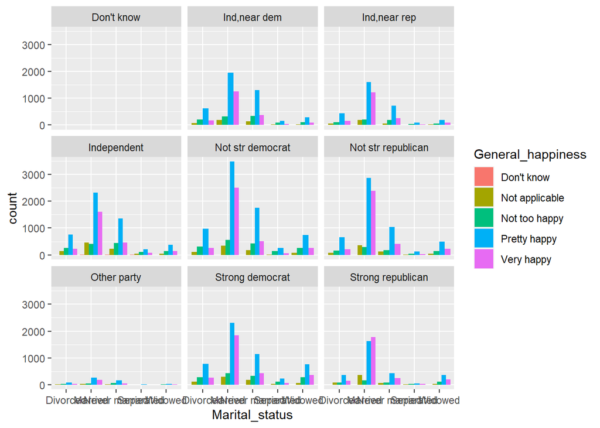

```r
#appropriate visualization
ggplot(partyAff, aes(x=Marital_status, fill=General_happiness))+geom_bar(position = position_dodge())+facet_wrap(~Political_party_affiliation)
```

The above graph shows the relationship in question 3 spread out depending on the respondents party affiliation. Using the graph I noticed that 3 categories seemingly stand out. It seems “Not str democrat” and “Not str republican” are the highest on the scale of happiness. The highest happiness being the difference in counts from the blue and purple to the green shown on the graph. The lowest seeming to be “Ind,near rep”, other party, and strong republican. The variables I used to show this graph were the same as question three but including political party affiliation to wrap and split the relationship up depending on the newly added variable categories.

#Question 5

#Explore an interesting question (not covered by the previous questions), and answer the question using the GSS data.

```r
#For this Question I will explore if the respondents sex changes how happy a respondent is compared to their marital status.

respondentSex = data %>% select(Marital_status, General_happiness, Respondents_sex)
respondentSex = respondentSex[!(respondentSex$General_happiness=="No answer"),]
respondentSex = respondentSex[!(respondentSex$Marital_status=="No answer"),]
respondentSex = respondentSex[!(respondentSex$Respondents_sex=="No answer"),]

#numerical summary
respondentSex %>% count(Marital_status, General_happiness, Respondents_sex, sort = TRUE)%>% print(n=48)
```

```
## # A tibble: 48 x 4
##    Marital_status General_happiness Respondents_sex     n
##    <chr>          <chr>             <chr>           <int>
##  1 Married        Pretty happy      Female           8511
##  2 Married        Pretty happy      Male             7982
##  3 Married        Very happy        Female           6917
##  4 Married        Very happy        Male             5932
##  5 Never married  Pretty happy      Male             4166
##  6 Never married  Pretty happy      Female           3788
##  7 Divorced       Pretty happy      Female           2855
##  8 Widowed        Pretty happy      Female           2652
##  9 Divorced       Pretty happy      Male             1828
## 10 Never married  Very happy        Female           1439
## 11 Never married  Very happy        Male             1293
## 12 Married        Not too happy     Male             1223
```

[output cut: 36 more lines]

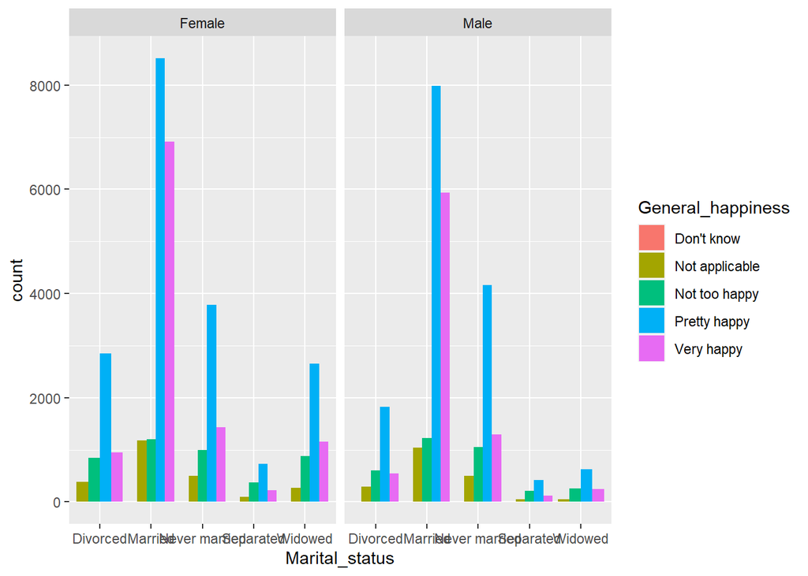

```r
#appropriate visualization
ggplot(respondentSex, aes(x=Marital_status, fill=General_happiness))+geom_bar(position = position_dodge())+facet_wrap(~Respondents_sex)
```

The graph above shows that female’s tend to be a bit happier in categories such as divorced, married, and widowed. Male’s seem to be a bit happier then females when never married. There also seems to be very little separated status responses but females tend to be happier in that response as well. The variables I used to show this include the same variables from question 3 and 4 but replacing the comparing variable to the relationship with a the respondent sex in order to compare effectively.